# Assignment #0 - Data and Visualization

**Due: Sep 10 (Tuesday) 11:00 pm**

**Sindhuja Kasula**

## Introduction

This notebook provides a walkthrough of the important concepts of Linear Algebra and Probability theory that are useful to understand the machine learning machine and deep learning algorithms and the math behind them, which helps in using the algorithms effectively to solve a problem. This review of linear algebra and probability theory can be used as quick cheatsheet with all the significant formulae and their explaination. Also this notebook provides step by step template for exploratory data analysis for Regression and Classification Problem. For each of the problem, this notebook has working code as well as good explaination on how to - read a dataset from csv file, explore the features of dataset to check the datatypes of features and statistical properties (like count , mean , max, standard deviation and quarantiles), to check for missing or invalid values ,to perform data preprocessing on dataset like encoding the categorical features to convert them to numbers and converting string format of date to datetime to extract more useful features for for machine learning algorithms and then how to visualize the different features of dataset to find patterns in among features and draw some preliminary observations based on patterns observed in visualizations. This notebook uses libraries Numpy, Pandas, datetime for data reading, data manipulations, feature extractions and feature scaling. And seaborn and matplotlib libraries for data visualization. Therefore, all the above mentioned libraries must be installed to successful running this notebook.Datasets are referenced from UCI and Kaggle whose references are mention in References section at the end of notebook.

## Review of Linear Algebra

To solve a machine learning and deep learning problem, it is important to know which algorithms can be applied on what kind of problems, to know this it is vital to understand the inner workings of algorithm, which usually is the mathematical equations and that is where linear algebra comes in picture. It is necessary to understand the different types of mathematical objects and their properties. The types of mathematical objects are - Scalars, Vectors, Matrices and Tensors.

Scalars are variables whose values are real numbers. They are reprsented with lower case italic font variable names.For instance, say we have variables ${s=9}$ ,${t=-9.06455}$ both $s$ and $t$ are scalars. Mathematically defined as ${n \epsilon R} $, where ${R}$ is the set of real number.

Vectors are an array of numbers, usually represented in bold face lower case variable name. The elements in vector are in order and can be accessed with the index suffixing the variable name. For instance ${a}$ is a vector which is defined as

$$ {a} = \begin{bmatrix} a_1 \\ a_2\\ . \\ . \\ a_n \end{bmatrix} $$

The length of vector is called {norm}, which is the distance from origin, mathematically represented as $ {|P|}_k = { \biggl(\sum_{n=1}^N (\mathbf{P}_{n})^k\biggr) }^\frac{1}{k} $ And k = 1 its a callled as ${L_1}$ norm which is sum of values in all axes while k=2 is called ${L_2}$ norm which is euclidian norm and is generally prefered. unit vectors are vectors with norm equals to one.

The significant vector operations are vector addition and vector multiplication. In vector addition, two vectors of same shape can only be added. And a scalar can also be added to a vector, here the scalar which is being added is shaped to size of vector and value is duplicated along the size, this is called broadcasting, which actually converts the whole whole to addition of two vectors.

Addition of two Vectors $$ {a} = \begin{bmatrix} a_1 \\ a_2\\ . \\ . \\ a_n \end{bmatrix} {b} = \begin{bmatrix} b_1 \\ b_2\\ . \\ . \\ b_n \end{bmatrix} {c} = {a} +{b} \\{c}= \begin{bmatrix} a_1 + b_1 \\ a_2 + b_2\\ . \\ . \\ a_n +b_n \end{bmatrix} $$

Adding a Scalar to a Vector $$ {a} = \begin{bmatrix} a_1 \\ a_2\\ . \\ . \\ a_n \end{bmatrix} b = 6 \\ {a} +{b} = \begin{bmatrix} a_1 + 6 \\ a_2 + 6\\ . \\ . \\ a_n + 6 \end{bmatrix} $$

Matrices are the two dimensional arrays, whose elements are accessed using row and column numbers. Matrix variables are represented using upper case letters in bold face. For instance matrix ${X}$ is defined as $$ X = \begin{bmatrix} x_{11} & x_{12} & \dots & x_{1D} \\ x_{21} & x_{22} & \dots & x_{2D} \\ \vdots & \vdots & \ddots & \vdots \\ x_{N1} & x_{N2} & \dots & x_{ND} \end{bmatrix}\\ $$

Most important matrix operations are Matrix Addition, Matrix Multiplication, Matrix Transpose and Inverse.

Matrix addition can be perfomed between matrices of same shape which same number of rows and columns in both, represented as ${C} = {A} + {B}$ where $ C_{i,j}= A_{i,j}+ B_{i,j}$ . A vector can be added to a matrix but it should have same size of a column or size of row. so the rest of are elements are duplicated by broadcasting, just like in vectors above, ${C} = {A} + {b}$ where C is matrix with i rows and j columns and b is a vector of size j, here the vaule of b is broadcated to rows $ C_{i,j}= A_{i,j}+ b_{j}$.

Matrix Multiplication is performed between matrices only when column size of first matrix is eqaul to row size of second matrix. first matrix $A_{i,j}$, second matrix $ B_{j,k}$, multiplied to form a new matrix C, given as $C_{i,k} = \sum_{k} A_{i,k}B_{k,j}$ . Scalar can also be multiplied to a matrix, which results in every element of matrix multiplied by scalar value. Matrix $A_{i,j}$ multiplied with ${b}$ $$ Ab = \begin{bmatrix} a_{11}b & a_{12}b & \dots & a_{1D}b \\ a_{21}b & a_{22}b & \dots & a_{2D}b \\ \vdots & \vdots & \ddots & \vdots \\ a_{N1}b & a_{N2}b & \dots & a_{ND}b \end{bmatrix}\\ $$

Element wise multiplication between matrices is called Hadamard product. Both matrices participating in this operation should have same number of rows and same number of columns, given as ${A.B}$ $$A_{i,j}.B_{i,j} = \begin{bmatrix} a_{11}b_{11} & a_{12}b_{12} & \dots & a_{1j}b_{1j}\\ a_{21}b_{21} & a_{22}b_{22} & \dots & a_{2j}b_{2j}\\ \vdots & \vdots & \ddots & \vdots \\ a_{i1}b_{i1} & a_{i2}b{i2} & \dots & a_{ij}b{ij} \end{bmatrix}\\ $$

Matrix Transpose is mirroring a matrix over its diagonal, rows become columns and viceversa. $$ X = \begin{bmatrix} x_{11} & x_{12} & x_{13} \\ x_{21} & x_{22} & x_{23} \end{bmatrix}\\ $$

Transpose of matrix X,$$ X^T = \begin{bmatrix} x_{11} & x_{12}\\ x_{21} & x_{22}\\ x_{31} & x_{32} \end{bmatrix} $$

Inverse of matrix can be computed only if matrix is non-singular, it is reprsented as $X^{-1}$. Diagnonal Matrix is matrix with only elements prsent across the matrix.An Identity Matrix is a diagonal matix with all diagonal elements as 1 and rest all as 0. Also, multiplication of a matrix with its inverse results in Identity matrix, ${A A^{-1} = I}$.A matrix is said to be Symmetric Matrix if one half of diagonal is mirror image of other, ${A = A^T}$. For a matrix to be Orthogonal, ${A^{-1} = A^T}$.

In few machine learning algorithms like PCA, the input is matrix should be reduced to lower dimensions,to do so Matrix Decomposition is applied. It can done using a methods called Eigen Decomposition where matrix is broken down to set of eigen vectors and eigen values, ${A = V diag(\lambda) V^{-1}}$, where ${V}$ is the matrix of eigen vectors and ${\lambda}$ is matrix of eigen values. Another method is Single Valued Decomposition which is more general form of eigen decomposition, where ${A= UVD^T}$ where {D} is a diagonal matrix with singular values of A, U is left singular values, V has right singular values and U, V are orthogonal to each other.

And lastly Tensors are arrays in more than two axes. For instance they can be used to represent unstructured data like images which have values in three dimensions.

## Review of Probability Theory

Probability theory is used to make and reason the uncertain statements, to derive uncertain statements from facts. The uncertainty occurs due to three main sources. One being incomplete modelling, for instance a it is very difficult to build a chat bot which understands all kinds of accents, languages and has knowledge of anything. But a chat bot which can satisfy set of use cases and in a language is simpler comparatively. The other source is incomplete observability, the famous game show problem of million behind a door of three doors, statistically if user changes switches option in second attempt has 66% winning chance than not switching but from user’s perspective its of equal chance. And the last source being the randomness in the system for example the shuffling of cards in a card game. And this uncertainty is measured with Probability, which has range [0,1] , with 1 meaning its certain for sure.

Probability is of two types – Frequentist and Bayesian. If the probability is calculated based on frequency of occurrence of an event, its Frequentist Probability. And probability calculated qualitatively based on degree of belief is Bayesian Probability. For instance, if a coin is flipped 10 times and it was heads 6 times and tail four times, then according to Frequentist Probability, probability of heads denoted with p followed by outcome in parenthesis, $$ p(heads) = 6/10 $$ and probability of tail,
$$ p(tail) = 1 – p(head) = 4/10 $$ But according to Bayesian Probability there are only two outcomes of coins, so both have equal probability which is $$ p(heads) = p(tails) = 1/2 $$

And the event itself is called the Random Variable which has random outcomes and it can be of two types discrete and continuous. In the previous coin flipping event, it is a discrete random variable. And how likely one or more random variables takes its different values is described by Probability distribution. Probability distribution for discrete random variable is called Probability Mass Function (PMF), denoted with P followed by event and its values in parenthesis.
$$ P(X=xi) = 1/k $$
PMF for more than one variable is called as joint probability. Probability distribution for continuous random variable is called Probability Density Function (PDF) which is integral of P(X) over the range of outcomes of X, which over all the outcomes is equal to 1.

Marginal Probability is useful when its required to find probability of subset of in a given set of variables,defined as follows $$ P(x=x)= \sum_{yi} P(x=x,y=yi). $$
And when it is required to find the probability of an event based on occurrence of another event it is called Conditional Probability, the probability of y given x is $$ P(y/x) = \frac{P(x, y)}{p(x)} $$ And any joint probability is decomposed to product of conditional probability as stated by chain rule. So,the joint probability of x and y is $$ P(x, y) = P(x/y)*P(y) = P(y/x)*P(x) $$ And substituting this in previous equation, $$ P(y/x) = \frac{(P(x/y)*P(y))}{P(x)} $$ This equation is known as Bayes rule. And if the occurrence of two events does not not depend on each other at all, if the events are independent of each other then the joint probability is the product of two indivisual probabilities. $$ P(x,y) = P(x)*P(y) $$ And sometimes the events may dependent of each other but independent with respect to other event then the two events are conditionally independent, $$ P(x,y,z) = (x/z)P(y/z) $$

Expected value, Variance, Standard Deviation and Covariance with respect to Probability distribution are important statistical concepts. Expected value is the average of some random variable X, the Variance of some random variable X is a measure of how much values in the distribution vary on average with respect to the mean. The square root of variance is Standard Deviation. Covariance is a measure of the joint probability for two random variables describing how the two variables are linearly related to each other. If the two random variables are independent then they have zero covariance but the reverse is not true as covariance only observes the linear relationship, the random variables may have non-linear relationship.

The common types of distributions for machine learning are – Bernoulli Distribution, Multinomial Distribution, Gaussian or Normal Distribution, Laplace or Exponential Distribution. Bernoulli Distribution is a distribution of single binary variable, for instance the coin flip event , it has only two outcomes. $$ P(X=x) = \phi^x * ((1 − \phi)^(1−x)) $$

While multinomial distribution is Bernoulli Distribution for random variable with k outcomes instead of just two. Both of these distribution so far are for discrete random variables. While the Gaussian and Laplace distributions are for continuous random variable.Gaussian distribution is defined as $$ N(x; \mu, \sigma^2) = \sqrt{\frac{1}{2\pi\sigma^2}} exp\Bigl(\frac{-(x-µ)^2}{2\pi\sigma^2}\Bigl) $$

where ${\mu}$ is mean and ${\sigma^2}$ is variance. This distribution has a bell shape whose central peak is determined by mean and width of curve is determined by variance. And laplace distribution is defined as $$ Laplace(x; \mu, \gamma) = \Bigl(\frac{1}{2\gamma}\Bigl) exp\Bigl(\frac{-abs(x-\mu)}{\gamma}\Bigl) $$ this has a sharp peak at arbitary point ${\mu}$.

The two most importnat functions used in deep learning are Logistic Sigmoid and Softmax function. Logistic Sigmoid function which is used to compute ${\phi}$ of Bernoulli distribution because it has range (0,1) and has a shape of smoothened step function. It is defined as $$ \sigma(x) = \frac{1}{1+ exp(-x)} $$

And Softmax function is used for predicting the parameters of normal distribution because it has range (0,${\inf}$), it has an elblow shaped function, defined as $$ \zeta(x) = log(1+exp(x)) $$

# REGRESSION

## Introduction of data for Regression & source

The dataset I chose for regression is Indian Metro Dataset from Kaggle Repository ( link: https://www.kaggle.com/umairnsr87/indian-metro-data ). This dataset has information about the traffic volume observed during 2012- 2017 recorded on different timestamps a day and also on holidays with the weather conditions like temperature, wind speed, wind direction, different weather types, rainfall ph and snow ph which can be major determinants of traffic volume. This dataset has 33750 entries with 14 attributes and 1 target varibale. The problem to this visualizing this dataset is the main attribute timestamp is a string which should be converted to datetime object in order to variations with respect to year, month, day and hour. The attributes of dataset are visulaized with respect to target target volume to detect any patterns and draw preliminary observation.

## Reading the Dataset

Using read_csv function from pandas library to read the dataset into a Dataframe. Then using info function to know the dataset which states there are 33750 input samples and 15 features. This dataset has four object featues weather_type which is string and has 11 different types of weather, another object feature is weather_description which is also a string with briefly describing weather type. date_time and is_holiday are other object types which are also string type. date_time is string formatted date time of when instance is recored and is_holiday is set of different holidays. The target variable is 'traffic_volume' which is an integer and the other attributes of data are weathear measurements like - wind_speed, wind_direction, rain ph, snow ph, the visibility in miles, dew, temperature, clouds, humidity and air pollution index recoreded as either float or integer which can have significant impact on traffic volume. using describe function to check the statistical aspects of int and float features. These values can give breif idea on scales of features. And checked for missing values or invalid values using isnull and isna functions from pandas library and any function from Numpy library to check, which resulted False in both the cases. And finally using head and tail functions to see first and last five instances of dataset respectively.

```python
# Importing libraries pandas , matplotlib and seaborn

import pandas as pd
import numpy as np
import matplotlib.pyplot as plt
import seaborn as sns

import warnings
warnings.filterwarnings('ignore')
```

```python
# Reading data

df_traffic = pd.read_csv('./IN_Metro_Traffic.csv')
```

```python
# Understaning the features and their data types

df_traffic.info()
```

```
<class 'pandas.core.frame.DataFrame'>
RangeIndex: 33750 entries, 0 to 33749
Data columns (total 15 columns):
date_time              33750 non-null object
is_holiday             33750 non-null object
air_pollution_index    33750 non-null int64
humidity               33750 non-null int64
wind_speed             33750 non-null int64
wind_direction         33750 non-null int64
visibility_in_miles    33750 non-null int64
dew_point              33750 non-null int64
temperature            33750 non-null float64
rain_p_h               33750 non-null float64
snow_p_h               33750 non-null float64
clouds_all             33750 non-null int64
weather_type           33750 non-null object
weather_description    33750 non-null object
traffic_volume         33750 non-null int64
dtypes: float64(3), int64(8), object(4)
memory usage: 3.9+ MB
```

```python
# learning the information about features

df_traffic.describe()
```

|  | air_pollution_index | humidity | wind_speed | wind_direction | visibility_in_miles | dew_point | temperature | rain_p_h | snow_p_h | clouds_all | traffic_volume |
| --- | --- | --- | --- | --- | --- | --- | --- | --- | --- | --- | --- |
| count | 33750.000000 | 33750.000000 | 33750.000000 | 33750.000000 | 33750.000000 | 33750.000000 | 33750.000000 | 33750.000000 | 33750.000000 | 33750.000000 | 33750.000000 |
| mean | 154.841422 | 71.209007 | 3.378193 | 199.471852 | 4.989748 | 4.989748 | 280.069587 | 0.448739 | 0.000318 | 50.458785 | 3240.118163 |
| std | 83.735515 | 16.852248 | 2.055792 | 99.841088 | 2.570021 | 2.570021 | 13.415256 | 53.526500 | 0.009760 | 38.871734 | 1991.487289 |
| min | 10.000000 | 13.000000 | 0.000000 | 0.000000 | 1.000000 | 1.000000 | 0.000000 | 0.000000 | 0.000000 | 0.000000 | 0.000000 |
| 25% | 83.000000 | 60.000000 | 2.000000 | 130.000000 | 3.000000 | 3.000000 | 271.720000 | 0.000000 | 0.000000 | 1.000000 | 1165.250000 |
| 50% | 155.000000 | 72.000000 | 3.000000 | 200.000000 | 5.000000 | 5.000000 | 280.150000 | 0.000000 | 0.000000 | 64.000000 | 3335.000000 |
| 75% | 228.000000 | 85.000000 | 5.000000 | 290.000000 | 7.000000 | 7.000000 | 290.620000 | 0.000000 | 0.000000 | 90.000000 | 4926.000000 |
| max | 299.000000 | 100.000000 | 16.000000 | 360.000000 | 9.000000 | 9.000000 | 308.240000 | 9831.300000 | 0.510000 | 100.000000 | 7280.000000 |

```python
# checking for invalid values in dataset

np.any(df_traffic.isna())
```

```
False
```

```python
# checking for null/missing values in dataset

np.any(df_traffic.isnull())
```

```
False
```

```python
# Preview of first five instances
df_traffic.head(5)
```

|  | date_time | is_holiday | air_pollution_index | humidity | wind_speed | wind_direction | visibility_in_miles | dew_point | temperature | rain_p_h | snow_p_h | clouds_all | weather_type | weather_description | traffic_volume |
| --- | --- | --- | --- | --- | --- | --- | --- | --- | --- | --- | --- | --- | --- | --- | --- |
| 0 | 2012-10-02 09:00:00 | None | 121 | 89 | 2 | 329 | 1 | 1 | 288.28 | 0.0 | 0.0 | 40 | Clouds | scattered clouds | 5545 |
| 1 | 2012-10-02 10:00:00 | None | 178 | 67 | 3 | 330 | 1 | 1 | 289.36 | 0.0 | 0.0 | 75 | Clouds | broken clouds | 4516 |
| 2 | 2012-10-02 11:00:00 | None | 113 | 66 | 3 | 329 | 2 | 2 | 289.58 | 0.0 | 0.0 | 90 | Clouds | overcast clouds | 4767 |
| 3 | 2012-10-02 12:00:00 | None | 20 | 66 | 3 | 329 | 5 | 5 | 290.13 | 0.0 | 0.0 | 90 | Clouds | overcast clouds | 5026 |
| 4 | 2012-10-02 13:00:00 | None | 281 | 65 | 3 | 329 | 7 | 7 | 291.14 | 0.0 | 0.0 | 75 | Clouds | broken clouds | 4918 |

```python
# Preview of last five instances
df_traffic.tail(5)
```

|  | date_time | is_holiday | air_pollution_index | humidity | wind_speed | wind_direction | visibility_in_miles | dew_point | temperature | rain_p_h | snow_p_h | clouds_all | weather_type | weather_description | traffic_volume |
| --- | --- | --- | --- | --- | --- | --- | --- | --- | --- | --- | --- | --- | --- | --- | --- |
| 33745 | 2017-05-17 21:00:00 | None | 74 | 85 | 1 | 328 | 7 | 7 | 287.88 | 0.0 | 0.0 | 90 | Mist | mist | 2348 |
| 33746 | 2017-05-17 22:00:00 | None | 81 | 70 | 1 | 24 | 2 | 2 | 286.95 | 0.0 | 0.0 | 90 | Rain | heavy intensity rain | 2194 |
| 33747 | 2017-05-17 22:00:00 | None | 138 | 70 | 1 | 24 | 1 | 1 | 286.95 | 0.0 | 0.0 | 90 | Mist | mist | 2194 |
| 33748 | 2017-05-17 23:00:00 | None | 229 | 66 | 1 | 42 | 6 | 6 | 285.75 | 0.0 | 0.0 | 90 | Rain | heavy intensity rain | 1328 |
| 33749 | 2017-05-17 23:00:00 | None | 140 | 63 | 1 | 27 | 8 | 8 | 285.75 | 0.0 | 0.0 | 90 | Mist | mist | 1328 |

## Preprocessing of the data

Categorial feature 'is_Holiday' is converted to boolean 1 if its a holiday and 0 it is not a holiday. And then encoded the enother categorical feature 'weather_type' by manually marking different type a value based on the severity in a dictionary and swapping the keys with values in the dataframe column. Next transforming the 'date_time' which is of string type to datetime object to extract information which can used to observe trends with year, month, day, hour, day of the week and also extracting information if it is a weekend. The days of weekday are encoded as integers with Monday as 1 and Sunday as 7. And the weekend feature is 1 if day of week is either Saturday(6) or Sunday(7) and 0 for other days. The other categorial feature this dataset has is 'weather_description', on investing the values of the feature, they breifly describe weather type in a single sentence and is of case sensitive, converting the text to lower so to categorize better. But since the weather_type provides enough information for visualization. This feature can be redundant. So next is dropping the redundant features from dataset - 'weather_description' and 'date_time', which is also now redundant as all information it can provide is mapped to new columns 'year', 'month', 'day','hour','weekday'and 'is_weekend'. The numerical features which are 'air_pollution_index', 'humidity', 'wind_speed', 'wind_direction','clouds_all','temperature', 'visibility_in_miles', 'dew_point', 'rain_p_h' are feature scaled using MinMax Normalization which is defined as $$ input val= \frac{input value - min val}{(max val- min val)} $$ And the preview of the newly transformed dataset is viewed with head function. Now except for the categorical columns and target, all the others have a range of [0, 1] which is displayed with describe function

```python
df_traffic.is_holiday.value_counts()
```

```
None                         33707
New Years Day                    5
Thanksgiving Day                 5
Christmas Day                    5
Washingtons Birthday             4
Veterans Day                     4
Columbus Day                     4
Labor Day                        4
Independence Day                 3
State Fair                       3
Martin Luther King Jr Day        3
Memorial Day                     3
Name: is_holiday, dtype: int64
```

```python
def isHolidayBool(x):
    if x== 'None':
        return 0
    else:
        return 1

df_traffic.is_holiday= df_traffic.is_holiday.apply(lambda x : isHolidayBool(x))
df_traffic.is_holiday.value_counts()
```

```
0    33707
1       43
Name: is_holiday, dtype: int64
```

```python
df_traffic.weather_type.value_counts()
```

```
Clouds          11213
Clear            9233
Mist             4047
Rain             3940
Snow             2070
Drizzle          1204
Haze              902
Fog               567
Thunderstorm      553
Smoke              17
Squall              4
Name: weather_type, dtype: int64
```

```python
# manually encoding the labels to assign the weather scale

weather_type_dic = {'Clouds':1, 'Clear':0, 'Mist':2, 'Rain':5, 'Snow':10, 'Drizzle':6, 'Haze':3,
                    'Fog':4, 'Thunderstorm':9, 'Smoke':7, 'Squall':8}

df_traffic.weather_type = df_traffic.weather_type.apply(lambda x : weather_type_dic[x])

df_traffic.weather_type.value_counts()
```

```
1     11213
0      9233
2      4047
5      3940
10     2070
6      1204
3       902
4       567
9       553
7        17
8         4
Name: weather_type, dtype: int64
```

```python
from datetime import datetime
print(df_traffic.date_time[4])
print(type(df_traffic.date_time[4]))
datetime.strptime(df_traffic.date_time[4], '%Y-%m-%d %H:%M:%S')
```

```
2012-10-02 13:00:00
<class 'str'>
```

```
datetime.datetime(2012, 10, 2, 13, 0)
```

```python
datetime.strptime(df_traffic.date_time[4], '%Y-%m-%d %H:%M:%S').isoweekday()
```

```
2
```

```python
def isWeekend(day):
    if day in [6,7]:
        return 1
    else:
        return 0
```

```python
df_traffic["date_time"] = df_traffic["date_time"].apply(lambda x: datetime.strptime(x,'%Y-%m-%d %H:%M:%S'))
df_traffic["year"] = df_traffic["date_time"].apply(lambda x: x.year)
df_traffic["month"] = df_traffic["date_time"].apply(lambda x: x.month)
df_traffic["day"] = df_traffic["date_time"].apply(lambda x: x.day)
df_traffic["hour"] = df_traffic["date_time"].apply(lambda x: x.hour)
df_traffic["weekday"] = df_traffic["date_time"].apply(lambda x: x.isoweekday())
df_traffic["is_weekend"] = df_traffic["weekday"].apply(lambda x: isWeekend(x))
```

```python
df_traffic.weather_description.value_counts()
```

```
sky is clear                           7524
mist                                   4047
overcast clouds                        3972
broken clouds                          3379
light rain                             2442
scattered clouds                       2294
Sky is Clear                           1709
few clouds                             1568
light snow                             1280
moderate rain                          1105
haze                                    902
light intensity drizzle                 703
heavy snow                              587
fog                                     567
drizzle                                 460
proximity thunderstorm                  345
heavy intensity rain                    311
snow                                    190
thunderstorm                             66
proximity shower rain                    54
thunderstorm with heavy rain             42
heavy intensity drizzle                  40
thunderstorm with light rain             35
proximity thunderstorm with rain         25
thunderstorm with rain                   23
very heavy rain                          18
smoke                                    17
proximity thunderstorm with drizzle      11
light intensity shower rain               8
light rain and snow                       6
thunderstorm with light drizzle           4
light shower snow                         4
SQUALLS                                   4
freezing rain                             2
sleet                                     2
thunderstorm with drizzle                 2
shower drizzle                            1
shower snow                               1
Name: weather_description, dtype: int64
```

```python
## converting the text to lower, so to catagorize better

df_traffic.weather_description = df_traffic.weather_description.apply(lambda x:x.lower())
```

```python
df_traffic.weather_description.value_counts()
```

```
sky is clear                           9233
mist                                   4047
overcast clouds                        3972
broken clouds                          3379
light rain                             2442
scattered clouds                       2294
few clouds                             1568
light snow                             1280
moderate rain                          1105
haze                                    902
light intensity drizzle                 703
heavy snow                              587
fog                                     567
drizzle                                 460
proximity thunderstorm                  345
heavy intensity rain                    311
snow                                    190
thunderstorm                             66
proximity shower rain                    54
thunderstorm with heavy rain             42
heavy intensity drizzle                  40
thunderstorm with light rain             35
proximity thunderstorm with rain         25
thunderstorm with rain                   23
very heavy rain                          18
smoke                                    17
proximity thunderstorm with drizzle      11
light intensity shower rain               8
light rain and snow                       6
thunderstorm with light drizzle           4
light shower snow                         4
squalls                                   4
freezing rain                             2
thunderstorm with drizzle                 2
sleet                                     2
shower snow                               1
shower drizzle                            1
Name: weather_description, dtype: int64
```

```python
df_traffic = df_traffic.drop(['date_time','weather_description'],axis = 1)
```

```python
def MinMaxNormalization(df, col_list):
    for col in col_list:
        print("** Started transforming "+col+"**")
        df_col_min = df[col].min()
        df_col_max = df[col].max()
        print(str(col)+"- min value is "+str(df_col_min)+", max value is "+str(df_col_max))
        df[col] = df[col].apply(lambda x: (x-df_col_min)/(df_col_max-df_col_min))
        print("** Finished transforming "+col+"**")
        print("\n")
    return df
```

```python
df_traffic = MinMaxNormalization(df_traffic, ['air_pollution_index', 'humidity', 'wind_speed', 'wind_direction','clouds_all','temperature','visibility_in_miles', 'dew_point', 'rain_p_h'])
```

```
** Started transforming air_pollution_index**
air_pollution_index- min value is 10, max value is 299
** Finished transforming air_pollution_index**


** Started transforming humidity**
humidity- min value is 13, max value is 100
** Finished transforming humidity**


** Started transforming wind_speed**
wind_speed- min value is 0, max value is 16
** Finished transforming wind_speed**


** Started transforming wind_direction**
wind_direction- min value is 0, max value is 360
** Finished transforming wind_direction**


** Started transforming clouds_all**
clouds_all- min value is 0, max value is 100
** Finished transforming clouds_all**


** Started transforming temperature**
temperature- min value is 0.0, max value is 308.24
** Finished transforming temperature**


** Started transforming visibility_in_miles**
visibility_in_miles- min value is 1, max value is 9
** Finished transforming visibility_in_miles**


** Started transforming dew_point**
dew_point- min value is 1, max value is 9
** Finished transforming dew_point**


** Started transforming rain_p_h**
rain_p_h- min value is 0.0, max value is 9831.3
** Finished transforming rain_p_h**
```

```python
df_traffic.head(15)
```

|  | is_holiday | air_pollution_index | humidity | wind_speed | wind_direction | visibility_in_miles | dew_point | temperature | rain_p_h | snow_p_h | clouds_all | weather_type | traffic_volume | year | month | day | hour | weekday | is_weekend |
| --- | --- | --- | --- | --- | --- | --- | --- | --- | --- | --- | --- | --- | --- | --- | --- | --- | --- | --- | --- |
| 0 | 0 | 0.384083 | 0.873563 | 0.1250 | 0.913889 | 0.000 | 0.000 | 0.935245 | 0.0 | 0.0 | 0.40 | 1 | 5545 | 2012 | 10 | 2 | 9 | 2 | 0 |
| 1 | 0 | 0.581315 | 0.620690 | 0.1875 | 0.916667 | 0.000 | 0.000 | 0.938749 | 0.0 | 0.0 | 0.75 | 1 | 4516 | 2012 | 10 | 2 | 10 | 2 | 0 |
| 2 | 0 | 0.356401 | 0.609195 | 0.1875 | 0.913889 | 0.125 | 0.125 | 0.939463 | 0.0 | 0.0 | 0.90 | 1 | 4767 | 2012 | 10 | 2 | 11 | 2 | 0 |
| 3 | 0 | 0.034602 | 0.609195 | 0.1875 | 0.913889 | 0.500 | 0.500 | 0.941247 | 0.0 | 0.0 | 0.90 | 1 | 5026 | 2012 | 10 | 2 | 12 | 2 | 0 |
| 4 | 0 | 0.937716 | 0.597701 | 0.1875 | 0.913889 | 0.750 | 0.750 | 0.944524 | 0.0 | 0.0 | 0.75 | 1 | 4918 | 2012 | 10 | 2 | 13 | 2 | 0 |
| 5 | 0 | 0.044983 | 0.597701 | 0.1875 | 0.911111 | 0.625 | 0.625 | 0.946405 | 0.0 | 0.0 | 0.01 | 0 | 5181 | 2012 | 10 | 2 | 14 | 2 | 0 |
| 6 | 0 | 0.602076 | 0.586207 | 0.1875 | 0.911111 | 0.750 | 0.750 | 0.951110 | 0.0 | 0.0 | 0.01 | 0 | 5584 | 2012 | 10 | 2 | 15 | 2 | 0 |
| 7 | 0 | 0.543253 | 0.586207 | 0.1875 | 0.908333 | 0.750 | 0.750 | 0.953348 | 0.0 | 0.0 | 0.01 | 0 | 6015 | 2012 | 10 | 2 | 16 | 2 | 0 |
| 8 | 0 | 0.377163 | 0.574713 | 0.1875 | 0.908333 | 0.625 | 0.625 | 0.954256 | 0.0 | 0.0 | 0.20 | 1 | 5791 | 2012 | 10 | 2 | 17 | 2 | 0 |
| 9 | 0 | 0.522491 | 0.574713 | 0.1875 | 0.905556 | 0.250 | 0.250 | 0.950882 | 0.0 | 0.0 | 0.20 | 1 | 4770 | 2012 | 10 | 2 | 18 | 2 | 0 |
| 10 | 0 | 0.806228 | 0.563218 | 0.1875 | 0.905556 | 0.875 | 0.875 | 0.943972 | 0.0 | 0.0 | 0.20 | 1 | 3539 | 2012 | 10 | 2 | 19 | 2 | 0 |
| 11 | 0 | 0.484429 | 0.563218 | 0.1875 | 0.905556 | 0.500 | 0.500 | 0.938814 | 0.0 | 0.0 | 0.01 | 0 | 2784 | 2012 | 10 | 2 | 20 | 2 | 0 |
| 12 | 0 | 0.408304 | 0.551724 | 0.2500 | 0.902778 | 0.375 | 0.375 | 0.936316 | 0.0 | 0.0 | 0.01 | 0 | 2361 | 2012 | 10 | 2 | 21 | 2 | 0 |
| 13 | 0 | 0.027682 | 0.551724 | 0.2500 | 0.902778 | 0.750 | 0.750 | 0.931612 | 0.0 | 0.0 | 0.01 | 0 | 1529 | 2012 | 10 | 2 | 22 | 2 | 0 |
| 14 | 0 | 0.608997 | 0.540230 | 0.2500 | 0.900000 | 0.500 | 0.500 | 0.926064 | 0.0 | 0.0 | 0.01 | 0 | 963 | 2012 | 10 | 2 | 23 | 2 | 0 |

```python
df_traffic.describe()
```

|  | is_holiday | air_pollution_index | humidity | wind_speed | wind_direction | visibility_in_miles | dew_point | temperature | rain_p_h | snow_p_h | clouds_all | weather_type | traffic_volume | year | month | day | hour | weekday | is_weekend |
| --- | --- | --- | --- | --- | --- | --- | --- | --- | --- | --- | --- | --- | --- | --- | --- | --- | --- | --- | --- |
| count | 33750.000000 | 33750.000000 | 33750.000000 | 33750.000000 | 33750.000000 | 33750.000000 | 33750.000000 | 33750.000000 | 33750.000000 | 33750.000000 | 33750.000000 | 33750.000000 | 33750.000000 | 33750.000000 | 33750.000000 | 33750.000000 | 33750.000000 | 33750.000000 | 33750.000000 |
| mean | 0.001274 | 0.501181 | 0.669069 | 0.211137 | 0.554088 | 0.498719 | 0.498719 | 0.908609 | 0.000046 | 0.000318 | 0.504588 | 2.282459 | 3240.118163 | 2014.639822 | 6.407674 | 15.646874 | 11.404385 | 3.982667 | 0.283200 |
| std | 0.035672 | 0.289742 | 0.193704 | 0.128487 | 0.277336 | 0.321253 | 0.321253 | 0.043522 | 0.005444 | 0.009760 | 0.388717 | 2.794174 | 1991.487289 | 1.572845 | 3.543241 | 8.700568 | 6.951078 | 2.005717 | 0.450559 |
| min | 0.000000 | 0.000000 | 0.000000 | 0.000000 | 0.000000 | 0.000000 | 0.000000 | 0.000000 | 0.000000 | 0.000000 | 0.000000 | 0.000000 | 0.000000 | 2012.000000 | 1.000000 | 1.000000 | 0.000000 | 1.000000 | 0.000000 |
| 25% | 0.000000 | 0.252595 | 0.540230 | 0.125000 | 0.361111 | 0.250000 | 0.250000 | 0.881521 | 0.000000 | 0.000000 | 0.010000 | 0.000000 | 1165.250000 | 2013.000000 | 3.000000 | 8.000000 | 5.000000 | 2.000000 | 0.000000 |
| 50% | 0.000000 | 0.501730 | 0.678161 | 0.187500 | 0.555556 | 0.500000 | 0.500000 | 0.908870 | 0.000000 | 0.000000 | 0.640000 | 1.000000 | 3335.000000 | 2015.000000 | 6.000000 | 16.000000 | 11.000000 | 4.000000 | 0.000000 |
| 75% | 0.000000 | 0.754325 | 0.827586 | 0.312500 | 0.805556 | 0.750000 | 0.750000 | 0.942837 | 0.000000 | 0.000000 | 0.900000 | 3.000000 | 4926.000000 | 2016.000000 | 10.000000 | 23.000000 | 17.000000 | 6.000000 | 1.000000 |
| max | 1.000000 | 1.000000 | 1.000000 | 1.000000 | 1.000000 | 1.000000 | 1.000000 | 1.000000 | 1.000000 | 0.510000 | 1.000000 | 10.000000 | 7280.000000 | 2017.000000 | 12.000000 | 31.000000 | 23.000000 | 7.000000 | 1.000000 |

## Visualization of the data

```python
sns.set_style('whitegrid')
```

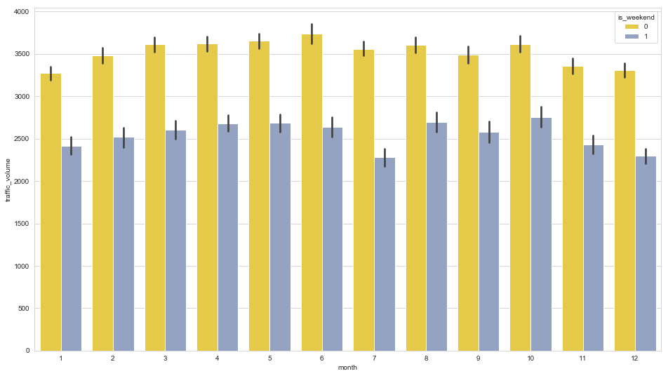

```python
plt.figure(figsize = (16,9))
sns.barplot(data=df_traffic, x= 'month', y='traffic_volume',palette='Set2_r', hue="is_weekend")
```

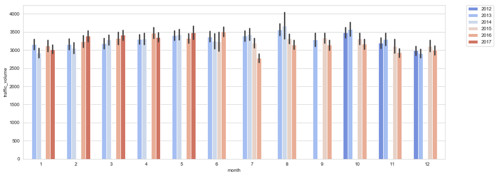

```python
plt.figure(figsize = (16,6))
sns.barplot(data=df_traffic, x= 'month', y='traffic_volume', hue='year', palette='coolwarm')
plt.legend(bbox_to_anchor=(1.05, 1), loc=2, borderaxespad=0.)
```

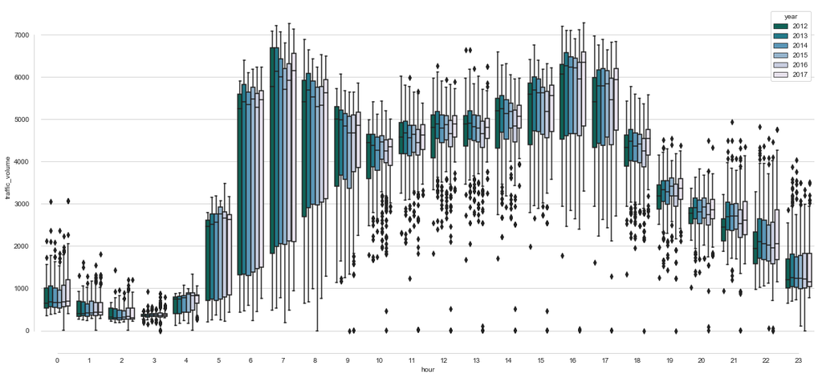

```python
plt.figure(figsize = (20,9))
#sns.violinplot(data=df_traffic, palette='PuBuGn_r', inner="hour")
sns.boxplot(x="hour", y="traffic_volume",hue="year", palette="PuBuGn_r",data=df_traffic)
sns.despine(offset=10, trim=True)
```

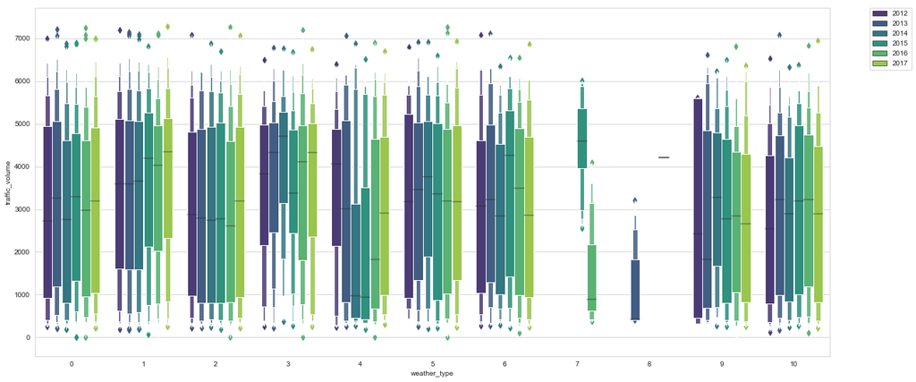

```python
plt.figure(figsize = (20,9))
sns.boxenplot(x="weather_type", y="traffic_volume", data=df_traffic, palette="viridis", hue='year')
plt.legend(bbox_to_anchor=(1.05, 1), loc=2, borderaxespad=0.)
```

### weather types

'Clear':0, 'Clouds':1, 'Mist':2, 'Haze':3, 'Fog':4, 'Rain':5, 'Drizzle':6, 'Smoke':7, 'Squall':8, 'Thunderstorm':9, 'Snow':10,

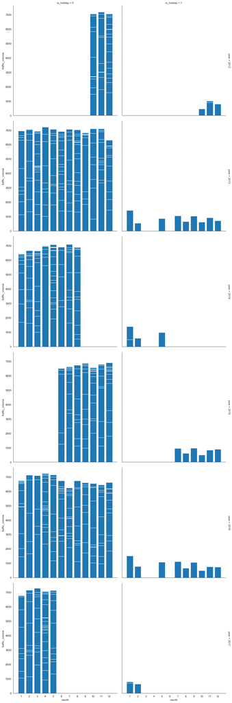

```python
plt.figure(figsize = (40,30))
g = sns.FacetGrid(df_traffic, col="is_holiday", row="year", margin_titles=True, height=6,aspect=1)
g.map(plt.bar, "month", "traffic_volume");
g.set(xticks=[1,2,3,4,5,6,7,8,9,10,11,12]);
```

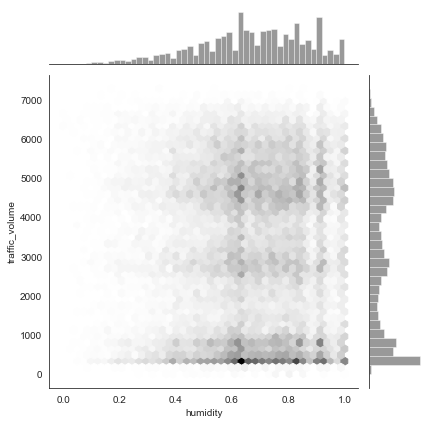

```python
sns.set_style("white")
sns.jointplot(x="humidity", y="traffic_volume", kind="hex", color="k", data = df_traffic);
```

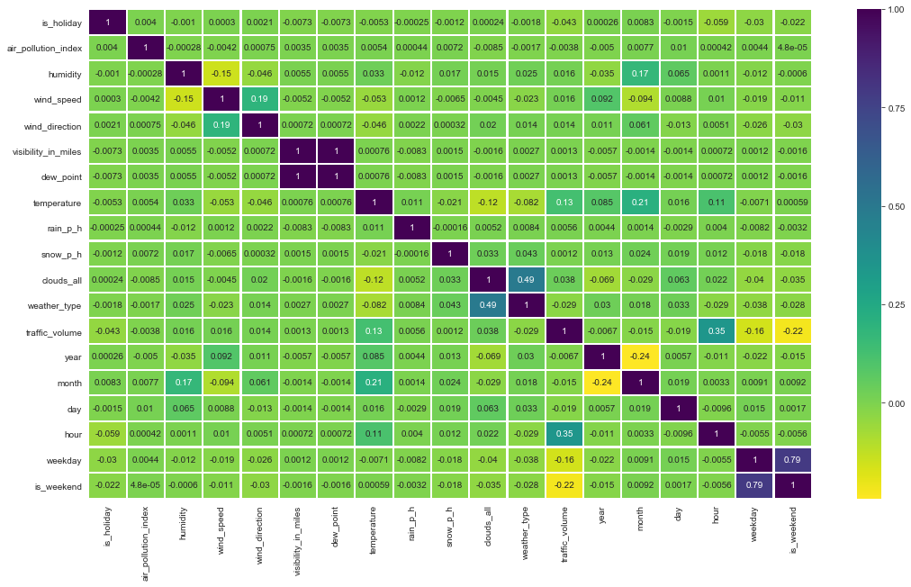

```python
df_traffic_corr = df_traffic.corr(method='pearson')
plt.figure(figsize = (18,10))
sns.heatmap(df_traffic_corr, cbar=True,cmap="viridis_r", linewidths=1.2,annot=True)
```

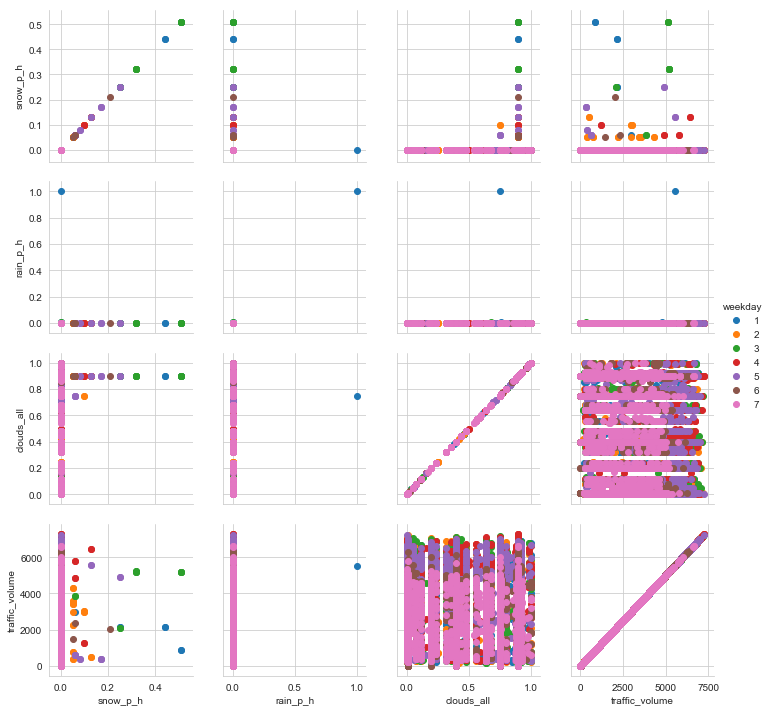

```python
sns.set_style('whitegrid')
g = sns.PairGrid(df_traffic, vars=["snow_p_h", 'rain_p_h', 'clouds_all',"traffic_volume" ], hue="weekday")
g.map(plt.scatter);
g.add_legend();
```

# CLASSIFICATION

## Introduction of data for Classification & source

The dataset I chose for classification is Online Shoppers Purchasing Intention Dataset from UCI Repository ( link:: https://archive.ics.uci.edu/ml/datasets/Online+Shoppers+Purchasing+Intention+Dataset ). This dataset has information about the online shoppers which can be used to classify whether the user would actually make any purchase or not, which is represented with target label 'Revenue' with True and False as values of this variable. The features which are used to analyse and classify user's intention are the different types of pages of the online website user visits and time spent on pages namely administrative pages, informational pages and product related pages. And the network based features like the type of traffic, Bounce rates, Exit rates, the region, the browers and operating systems of the users. The Page Value feature represents the average value for a web page that a user visited before completing an e-commerce transaction. The Special Day feature indicates the closeness of the site visiting time to a specific special day. The dataset also includes traffic type, visitor type as returning or new visitor, a Boolean value indicating whether the date of the visit is weekend, and month of the year.

## Reading the Dataset

Using read_csv function from pandas library to read the dataset into a Dataframe. Then using info function to know the dataset which states there are 12330 input samples and 18 features. This dataset has two boolean featues Weekend which is true if user visited website on weekend and viceversa and Revenue which is target label. There are also two object type featues which are VisitorType which provides information if a user is a returning user or new user or other and another feature being Month. All other remaing attributes are either integers or float. And checked for missing values or invalid values using isnull and isna functions from pandas library and any function from Numpy library to check, which resulted False in both the cases. And finally using head and tail functions to see first and last five instances of dataset respectively

```python
# Importing libraries pandas , matplotlib and seaborn

import pandas as pd
import numpy as np
import matplotlib.pyplot as plt
import seaborn as sns
```

```python
# Reading data
df_onlineShoppers = pd.read_csv('./online_shoppers_intention.csv')
```

```python
# checking the information of dataset
df_onlineShoppers.info()
```

```
<class 'pandas.core.frame.DataFrame'>
RangeIndex: 12330 entries, 0 to 12329
Data columns (total 18 columns):
Administrative             12330 non-null int64
Administrative_Duration    12330 non-null float64
Informational              12330 non-null int64
Informational_Duration     12330 non-null float64
ProductRelated             12330 non-null int64
ProductRelated_Duration    12330 non-null float64
BounceRates                12330 non-null float64
ExitRates                  12330 non-null float64
PageValues                 12330 non-null float64
SpecialDay                 12330 non-null float64
Month                      12330 non-null object
OperatingSystems           12330 non-null int64
Browser                    12330 non-null int64
Region                     12330 non-null int64
TrafficType                12330 non-null int64
VisitorType                12330 non-null object
Weekend                    12330 non-null bool
Revenue                    12330 non-null bool
dtypes: bool(2), float64(7), int64(7), object(2)
memory usage: 1.5+ MB
```

```python
# checking for null/missing values in dataset

np.any(df_onlineShoppers.isnull())
```

```
False
```

```python
# checking for invalid values in dataset

np.any(df_onlineShoppers.isna())
```

```
False
```

```python
# learning the information about features

df_onlineShoppers.describe()
```

|  | Administrative | Administrative_Duration | Informational | Informational_Duration | ProductRelated | ProductRelated_Duration | BounceRates | ExitRates | PageValues | SpecialDay | OperatingSystems | Browser | Region | TrafficType |
| --- | --- | --- | --- | --- | --- | --- | --- | --- | --- | --- | --- | --- | --- | --- |
| count | 12330.000000 | 12330.000000 | 12330.000000 | 12330.000000 | 12330.000000 | 12330.000000 | 12330.000000 | 12330.000000 | 12330.000000 | 12330.000000 | 12330.000000 | 12330.000000 | 12330.000000 | 12330.000000 |
| mean | 2.315166 | 80.818611 | 0.503569 | 34.472398 | 31.731468 | 1194.746220 | 0.022191 | 0.043073 | 5.889258 | 0.061427 | 2.124006 | 2.357097 | 3.147364 | 4.069586 |
| std | 3.321784 | 176.779107 | 1.270156 | 140.749294 | 44.475503 | 1913.669288 | 0.048488 | 0.048597 | 18.568437 | 0.198917 | 0.911325 | 1.717277 | 2.401591 | 4.025169 |
| min | 0.000000 | 0.000000 | 0.000000 | 0.000000 | 0.000000 | 0.000000 | 0.000000 | 0.000000 | 0.000000 | 0.000000 | 1.000000 | 1.000000 | 1.000000 | 1.000000 |
| 25% | 0.000000 | 0.000000 | 0.000000 | 0.000000 | 7.000000 | 184.137500 | 0.000000 | 0.014286 | 0.000000 | 0.000000 | 2.000000 | 2.000000 | 1.000000 | 2.000000 |
| 50% | 1.000000 | 7.500000 | 0.000000 | 0.000000 | 18.000000 | 598.936905 | 0.003112 | 0.025156 | 0.000000 | 0.000000 | 2.000000 | 2.000000 | 3.000000 | 2.000000 |
| 75% | 4.000000 | 93.256250 | 0.000000 | 0.000000 | 38.000000 | 1464.157213 | 0.016813 | 0.050000 | 0.000000 | 0.000000 | 3.000000 | 2.000000 | 4.000000 | 4.000000 |
| max | 27.000000 | 3398.750000 | 24.000000 | 2549.375000 | 705.000000 | 63973.522230 | 0.200000 | 0.200000 | 361.763742 | 1.000000 | 8.000000 | 13.000000 | 9.000000 | 20.000000 |

```python
# previewing first five instances

df_onlineShoppers.head(5)
```

|  | Administrative | Administrative_Duration | Informational | Informational_Duration | ProductRelated | ProductRelated_Duration | BounceRates | ExitRates | PageValues | SpecialDay | Month | OperatingSystems | Browser | Region | TrafficType | VisitorType | Weekend | Revenue |
| --- | --- | --- | --- | --- | --- | --- | --- | --- | --- | --- | --- | --- | --- | --- | --- | --- | --- | --- |
| 0 | 0 | 0.0 | 0 | 0.0 | 1 | 0.000000 | 0.20 | 0.20 | 0.0 | 0.0 | Feb | 1 | 1 | 1 | 1 | Returning_Visitor | False | False |
| 1 | 0 | 0.0 | 0 | 0.0 | 2 | 64.000000 | 0.00 | 0.10 | 0.0 | 0.0 | Feb | 2 | 2 | 1 | 2 | Returning_Visitor | False | False |
| 2 | 0 | 0.0 | 0 | 0.0 | 1 | 0.000000 | 0.20 | 0.20 | 0.0 | 0.0 | Feb | 4 | 1 | 9 | 3 | Returning_Visitor | False | False |
| 3 | 0 | 0.0 | 0 | 0.0 | 2 | 2.666667 | 0.05 | 0.14 | 0.0 | 0.0 | Feb | 3 | 2 | 2 | 4 | Returning_Visitor | False | False |
| 4 | 0 | 0.0 | 0 | 0.0 | 10 | 627.500000 | 0.02 | 0.05 | 0.0 | 0.0 | Feb | 3 | 3 | 1 | 4 | Returning_Visitor | True | False |

```python
# previewing last five instances

df_onlineShoppers.tail(5)
```

|  | Administrative | Administrative_Duration | Informational | Informational_Duration | ProductRelated | ProductRelated_Duration | BounceRates | ExitRates | PageValues | SpecialDay | Month | OperatingSystems | Browser | Region | TrafficType | VisitorType | Weekend | Revenue |
| --- | --- | --- | --- | --- | --- | --- | --- | --- | --- | --- | --- | --- | --- | --- | --- | --- | --- | --- |
| 12325 | 3 | 145.0 | 0 | 0.0 | 53 | 1783.791667 | 0.007143 | 0.029031 | 12.241717 | 0.0 | Dec | 4 | 6 | 1 | 1 | Returning_Visitor | True | False |
| 12326 | 0 | 0.0 | 0 | 0.0 | 5 | 465.750000 | 0.000000 | 0.021333 | 0.000000 | 0.0 | Nov | 3 | 2 | 1 | 8 | Returning_Visitor | True | False |
| 12327 | 0 | 0.0 | 0 | 0.0 | 6 | 184.250000 | 0.083333 | 0.086667 | 0.000000 | 0.0 | Nov | 3 | 2 | 1 | 13 | Returning_Visitor | True | False |
| 12328 | 4 | 75.0 | 0 | 0.0 | 15 | 346.000000 | 0.000000 | 0.021053 | 0.000000 | 0.0 | Nov | 2 | 2 | 3 | 11 | Returning_Visitor | False | False |
| 12329 | 0 | 0.0 | 0 | 0.0 | 3 | 21.250000 | 0.000000 | 0.066667 | 0.000000 | 0.0 | Nov | 3 | 2 | 1 | 2 | New_Visitor | True | False |

## Preprocessing of the data

```python
monthdic = {'Jan': 1, 'Feb':2, 'Mar':3, 'Apr':4, 'May':5, 'June':6,
            'Jul': 7, 'Aug':8, 'Sep':9, 'Oct':10, 'Nov': 11, 'Dec': 12}

visitorTypeDic = {'Returning_Visitor':0, 'New_Visitor':1, 'Other':2}
changeBoolDic = {False: 0, True:1}
df_onlineShoppers['Month'] = df_onlineShoppers['Month'].apply(lambda x: monthdic[x])
df_onlineShoppers['VisitorType'] = df_onlineShoppers['VisitorType'].apply(lambda x: visitorTypeDic[x])
df_onlineShoppers['Weekend'] = df_onlineShoppers['Weekend'].apply(lambda x: changeBoolDic[x])
df_onlineShoppers['Revenue'] = df_onlineShoppers['Revenue'].apply(lambda x: changeBoolDic[x])
df_onlineShoppers.head()
```

|  | Administrative | Administrative_Duration | Informational | Informational_Duration | ProductRelated | ProductRelated_Duration | BounceRates | ExitRates | PageValues | SpecialDay | Month | OperatingSystems | Browser | Region | TrafficType | VisitorType | Weekend | Revenue |
| --- | --- | --- | --- | --- | --- | --- | --- | --- | --- | --- | --- | --- | --- | --- | --- | --- | --- | --- |
| 0 | 0 | 0.0 | 0 | 0.0 | 1 | 0.000000 | 0.20 | 0.20 | 0.0 | 0.0 | 2 | 1 | 1 | 1 | 1 | 0 | 0 | 0 |
| 1 | 0 | 0.0 | 0 | 0.0 | 2 | 64.000000 | 0.00 | 0.10 | 0.0 | 0.0 | 2 | 2 | 2 | 1 | 2 | 0 | 0 | 0 |
| 2 | 0 | 0.0 | 0 | 0.0 | 1 | 0.000000 | 0.20 | 0.20 | 0.0 | 0.0 | 2 | 4 | 1 | 9 | 3 | 0 | 0 | 0 |
| 3 | 0 | 0.0 | 0 | 0.0 | 2 | 2.666667 | 0.05 | 0.14 | 0.0 | 0.0 | 2 | 3 | 2 | 2 | 4 | 0 | 0 | 0 |
| 4 | 0 | 0.0 | 0 | 0.0 | 10 | 627.500000 | 0.02 | 0.05 | 0.0 | 0.0 | 2 | 3 | 3 | 1 | 4 | 0 | 1 | 0 |

```python
def standardize(inp,input_mean,input_max,input_min):

    """function to standarize and normalize columns"""
    inp = (inp- input_mean)/(input_max- input_min)


    return inp
```

```python
# Feature Scaling

df_onlineShoppers['Administrative_Duration'] = df_onlineShoppers['Administrative_Duration'].apply(lambda x : standardize(x,df_onlineShoppers['Administrative_Duration'].mean(),
                                            df_onlineShoppers['Administrative_Duration'].max(),df_onlineShoppers['Administrative_Duration'].min()))

df_onlineShoppers['Informational_Duration'] = df_onlineShoppers['Informational_Duration'].apply(lambda x : standardize(x,df_onlineShoppers['Informational_Duration'].mean(),
                                                    df_onlineShoppers['Informational_Duration'].max(),df_onlineShoppers['Informational_Duration'].min()))

df_onlineShoppers['ProductRelated_Duration'] = df_onlineShoppers['ProductRelated_Duration'].apply(lambda x : standardize(x,df_onlineShoppers['ProductRelated_Duration'].mean(),
                                                                            df_onlineShoppers['ProductRelated_Duration'].max(),df_onlineShoppers['ProductRelated_Duration'].min()))

df_onlineShoppers['Administrative'] = df_onlineShoppers['Administrative'].apply(lambda x : standardize(x,df_onlineShoppers['Administrative'].mean(),
                                         df_onlineShoppers['Administrative'].max(),df_onlineShoppers['Administrative'].min()))

df_onlineShoppers['Informational'] = df_onlineShoppers['Informational'].apply(lambda x : standardize(x,df_onlineShoppers['Informational'].mean(),
                                             df_onlineShoppers['Informational'].max(),df_onlineShoppers['Informational'].min()))

df_onlineShoppers['ProductRelated'] = df_onlineShoppers['ProductRelated'].apply(lambda x : standardize(x,df_onlineShoppers['ProductRelated'].mean(),
                                             df_onlineShoppers['ProductRelated'].max(),df_onlineShoppers['ProductRelated'].min()))

df_onlineShoppers['PageValues'] = df_onlineShoppers['PageValues'].apply(lambda x : standardize(x,df_onlineShoppers['PageValues'].mean(),
                                            df_onlineShoppers['PageValues'].max(),df_onlineShoppers['PageValues'].min()))

df_onlineShoppers.head()
```

|  | Administrative | Administrative_Duration | Informational | Informational_Duration | ProductRelated | ProductRelated_Duration | BounceRates | ExitRates | PageValues | SpecialDay | Month | OperatingSystems | Browser | Region | TrafficType | VisitorType | Weekend | Revenue |
| --- | --- | --- | --- | --- | --- | --- | --- | --- | --- | --- | --- | --- | --- | --- | --- | --- | --- | --- |
| 0 | -0.085747 | -0.023779 | -0.020982 | -0.013522 | -0.043591 | -0.018676 | 0.20 | 0.20 | -0.016279 | 0.0 | 2 | 1 | 1 | 1 | 1 | 0 | 0 | 0 |
| 1 | -0.085747 | -0.023779 | -0.020982 | -0.013522 | -0.042172 | -0.017675 | 0.00 | 0.10 | -0.016279 | 0.0 | 2 | 2 | 2 | 1 | 2 | 0 | 0 | 0 |
| 2 | -0.085747 | -0.023779 | -0.020982 | -0.013522 | -0.043591 | -0.018676 | 0.20 | 0.20 | -0.016279 | 0.0 | 2 | 4 | 1 | 9 | 3 | 0 | 0 | 0 |
| 3 | -0.085747 | -0.023779 | -0.020982 | -0.013522 | -0.042172 | -0.018634 | 0.05 | 0.14 | -0.016279 | 0.0 | 2 | 3 | 2 | 2 | 4 | 0 | 0 | 0 |
| 4 | -0.085747 | -0.023779 | -0.020982 | -0.013522 | -0.030825 | -0.008867 | 0.02 | 0.05 | -0.016279 | 0.0 | 2 | 3 | 3 | 1 | 4 | 0 | 1 | 0 |

## Visualization of the data

Firstly, the instances are visualized based on the count of Revenue, which is 1 if user purchased something and 0 if user did not make any purchase. And then to analyse the variations in a feature with respect to other feature, the pearson correlation is computed pairwise for all the features using corr function from pandas library and the resultant correlation dataframe is visualized as a heatmap with annoted values and colorbar showing the contrast between least related and most related features. The pairwise scatter plots are plotted for most correlated features - 'Administrative', 'Administrative_Duration', 'Informational','Informational_Duration', 'ProductRelated' and 'ProductRelated_Duration'. And the revenue is visualized during all the months with special days and weekends.Also, during which months different types of users namely returning users, new users and others add to revenue is visualized using a scatter plot. Also, the PageValues for for different months is displyed using a scatter plot. The target variable 'Revenue' is plotted against BounceRates and ExitRates as scatterplot while plotting the ordinal features 'Opertaing System', 'Region', 'Browser', 'Traffic Type' to explore for patterns.

```python
# seting the background for seaborn plots

sns.set_style('whitegrid')
```

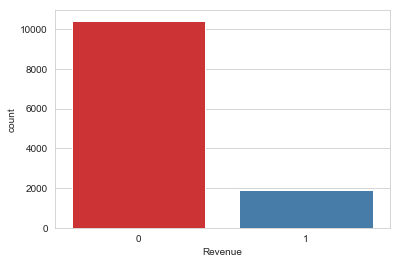

```python
# plotting the count of instances which added revenue and which did not

sns.countplot(data=df_onlineShoppers , x= 'Revenue',palette='Set1')
```

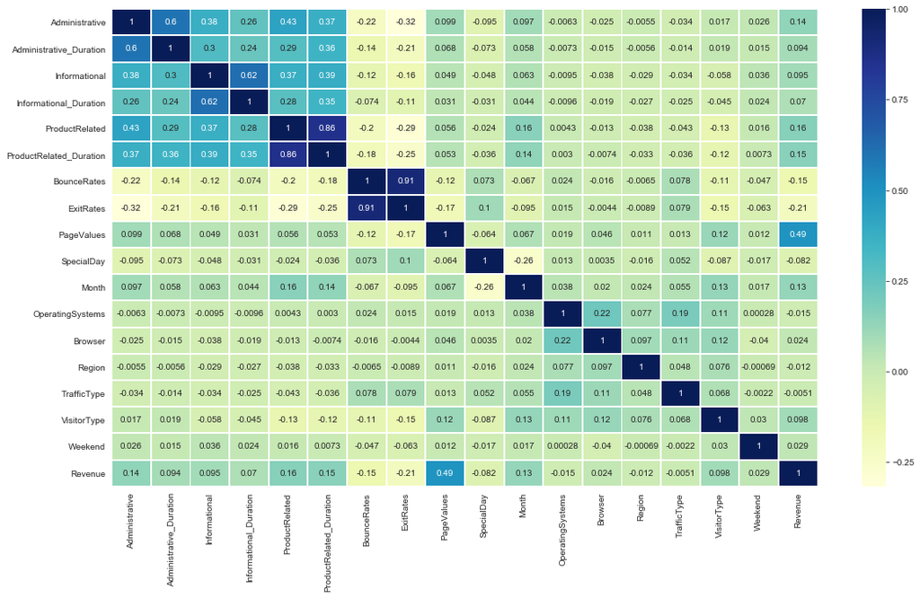

```python
# calculating the correlation and plotting the heatmap of correlation dataframe

df_corr = df_onlineShoppers.corr(method='pearson')
plt.figure(figsize = (18,10))
g = sns.heatmap(df_corr, cbar=True,cmap="YlGnBu", linewidths=0.9,annot=True)
g
```

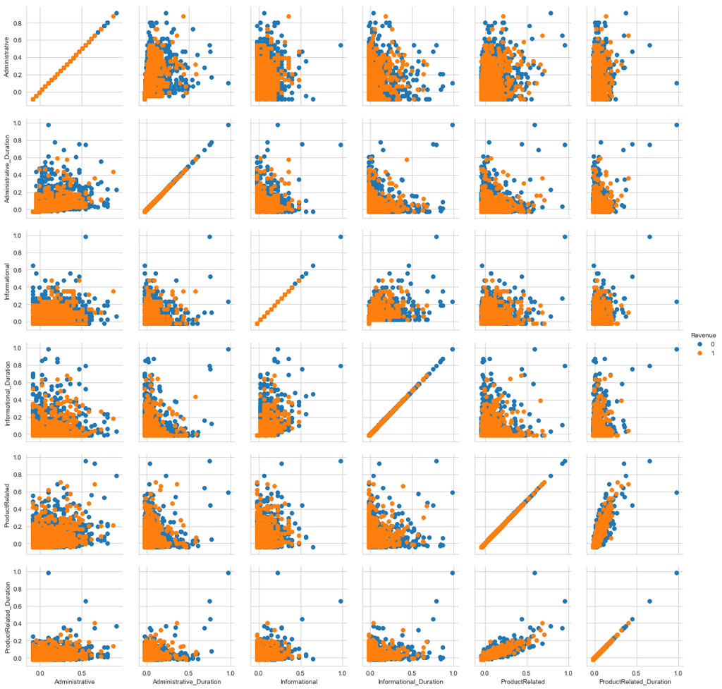

```python
# Plotting pair plots for 'Administrative', 'Administrative_Duration', 'Informational',
# 'Informational_Duration', 'ProductRelated', 'ProductRelated_Duration' features to check the patterns among them

g = sns.PairGrid(df_onlineShoppers, vars=[ 'Administrative', 'Administrative_Duration', 'Informational',
       'Informational_Duration', 'ProductRelated', 'ProductRelated_Duration'], hue="Revenue")
g.map(plt.scatter);
g.add_legend();
```

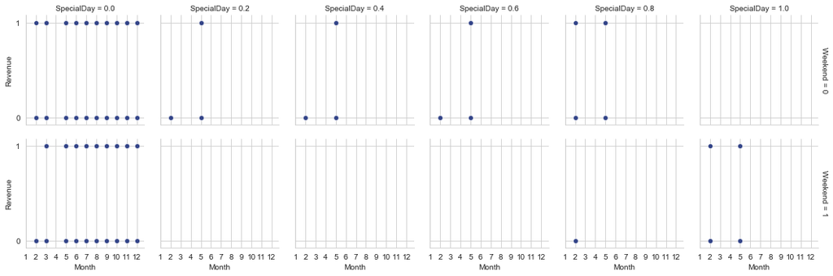

```python
g = sns.FacetGrid(df_onlineShoppers, col="SpecialDay", row="Weekend", margin_titles=True, height=2.5)
g.map(plt.scatter, "Month", "Revenue", color="#334488", edgecolor="white", lw=.5 );
g.set(xticks=[1,2,3,4,5,6,7,8,9,10,11,12], yticks=[0,1]);
```

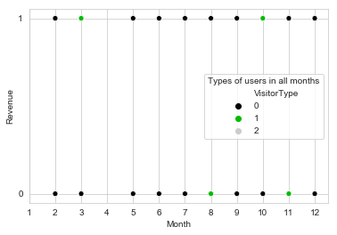

```python
g = sns.scatterplot(data = df_onlineShoppers, x='Month', y= 'Revenue', hue='VisitorType', palette='nipy_spectral' )
g.set(xticks=[1,2,3,4,5,6,7,8,9,10,11,12], yticks=[0,1]);
plt.legend(title='Types of users in all months', loc='center right')
```

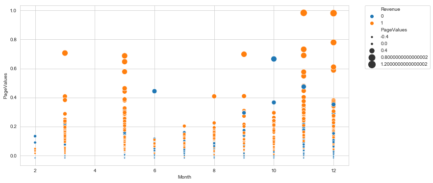

```python
#sns.countplot(data = df_onlineShoppers , x= "TrafficType", hue="Revenue")
plt.figure(figsize = (12,6))
sns.scatterplot(data = df_onlineShoppers , x= "Month", y ="PageValues", hue="Revenue", sizes=(10,200), size="PageValues")
plt.legend(bbox_to_anchor=(1.05, 1), loc=2, borderaxespad=0.)
```

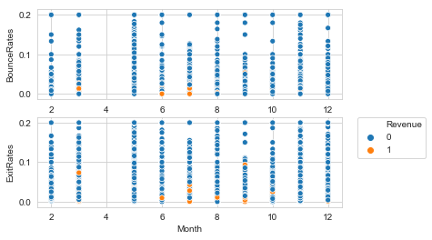

```python
f, axes = plt.subplots(2,1)
g = sns.scatterplot(x='Month', y='BounceRates',hue='Revenue', data=df_onlineShoppers, ax= axes[0], lw=1.5, legend=False )
g = sns.scatterplot(x='Month', y='ExitRates', hue='Revenue', data=df_onlineShoppers, ax= axes[1], lw=0.5)
plt.legend(bbox_to_anchor=(1.05, 1), loc=2, borderaxespad=0.)
```

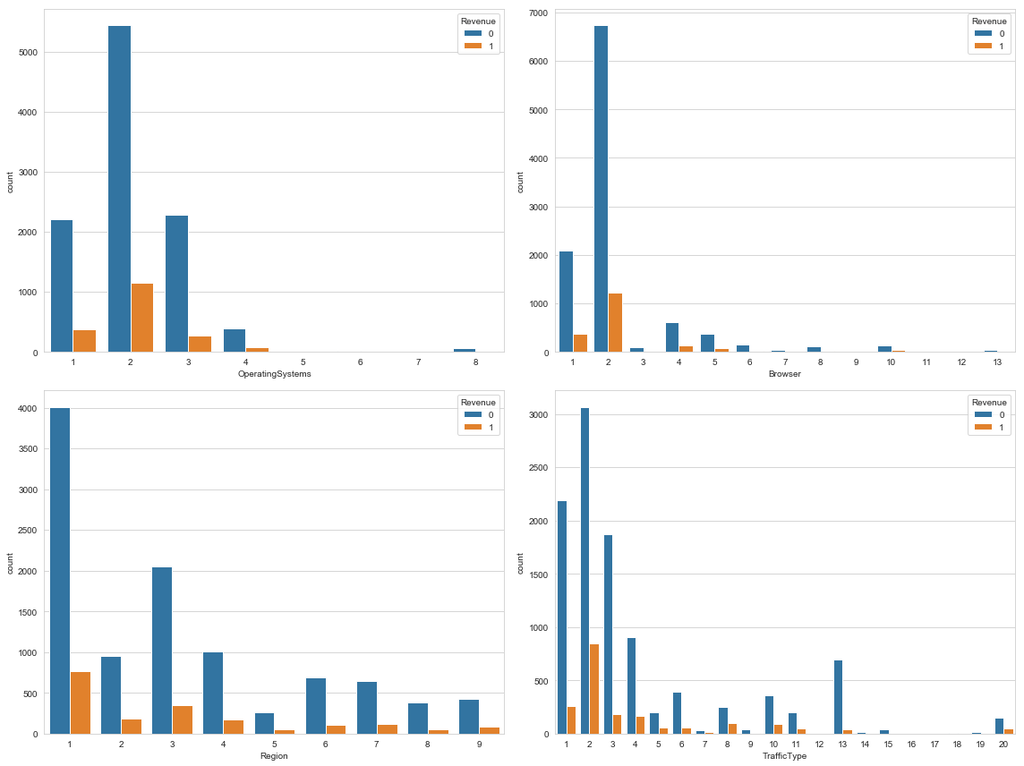

```python
fig = plt.figure(figsize=(16,12))
plt.clf()
col =['OperatingSystems', 'Browser', 'Region', 'TrafficType']
for i in range(4):
    plt.subplot(2,2,i+1 )
    sns.countplot(data = df_onlineShoppers, hue = 'Revenue', x = col[i])
    plt.xlabel(col[i])
fig.tight_layout()
```

## References

Sakar, C.O., Polat, S.O., Katircioglu, M. et al. Neural Comput & Applic (2018).

Ian Goodfellow , Yoshua Bengio , Aaron Courville, Deep Learning, MIT Press (2016).

Dataset Source Kaggle https://www.kaggle.com/umairnsr87/indian-metro-data UCI Repository https://archive.ics.uci.edu/ml/datasets/Online+Shoppers+Purchasing+Intention+Dataset

Web References :

https://pandas.pydata.org/pandas-docs/stable/reference/api/pandas.DataFrame.corr.html

https://seaborn.pydata.org/examples/scatterplot_sizes.html